# AE3_Analysis_Top_1000_IMDb_Movies

**1. Project Overview:** Objective & Data Source:

**2. Data Preparation:** Loading & Cleaning:

- Before diving into the analysis, I needed to clean and organize the dataset so it’s easier to work with. First, I removed columns that weren’t useful for the project, like *Poster_Link* (contains only image URLs, which are not useful for EDA or modeling.) and the cast members (*Star1, Star2, Star3, Star4*) (contain cast details, which are not essential for the current analysis). This allowed me to focus on the key information like ratings, genres, and revenue.
- Next, I ensured all the data types were in the right format. For example, the *Runtime* column included the word "min" at the end, so I cleaned that up and converted it into a numeric value. I also addressed the *Gross* column by removing commas and turning it into a proper numeric format, so I can perform calculations with it.
- I made sure the *Release_Year* was in the correct numeric format, which is important for creating time-based graphs.
- I also checked for missing values, especially in critical columns like *Meta_score* and *Gross*, and handled them by dropping rows with missing data.
- To ensure the dataset was consistent, I removed any duplicate rows, just in case a movie was listed more than once.
- Lastly, I renamed columns for clarity, such as changing *Series_Title* to *Title*, making the dataset more readable and ready for analysis.

This step reduces noise in the dataset and improves clarity for further analysis.

```python
import pandas as pd

# Load the dataset
df = pd.read_csv("imdb_top_1000.csv")

# Remove unnecessary columns: 'Poster_Link', 'Star1', 'Star2', 'Star3', 'Star4'
df.drop(columns=['Poster_Link', 'Star1', 'Star2', 'Star3', 'Star4'], inplace=True)

# Rename columns for clarity
df.rename(columns={'Series_Title': 'Title'}, inplace=True)

# Convert 'Runtime' from string ("142 min") to numeric
df['Runtime'] = df['Runtime'].str.replace(' min', '', regex=False).astype(float)

# Clean 'Gross' by removing commas and converting to float
df['Gross'] = df['Gross'].str.replace(',', '', regex=False)
df['Gross'] = pd.to_numeric(df['Gross'], errors='coerce')  # Convert invalid parsing to NaN

# Ensure 'Released_Year' is numeric
df['Released_Year'] = pd.to_numeric(df['Released_Year'], errors='coerce')

# Handle missing values: drop rows with missing Meta_score or Gross
df.dropna(subset=['Meta_score', 'Gross'], inplace=True)

# Remove duplicate rows if any
df.drop_duplicates(inplace=True)

# Display cleaned data
df.head()
```

|  | Title | Released_Year | Certificate | Runtime | Genre | IMDB_Rating | Overview | Meta_score | Director | No_of_Votes | Gross |
| --- | --- | --- | --- | --- | --- | --- | --- | --- | --- | --- | --- |
| 0 | The Shawshank Redemption | 1994.0 | A | 142.0 | Drama | 9.3 | Two imprisoned men bond over a number of years... | 80.0 | Frank Darabont | 2343110 | 28341469.0 |
| 1 | The Godfather | 1972.0 | A | 175.0 | Crime, Drama | 9.2 | An organized crime dynasty's aging patriarch t... | 100.0 | Francis Ford Coppola | 1620367 | 134966411.0 |
| 2 | The Dark Knight | 2008.0 | UA | 152.0 | Action, Crime, Drama | 9.0 | When the menace known as the Joker wreaks havo... | 84.0 | Christopher Nolan | 2303232 | 534858444.0 |
| 3 | The Godfather: Part II | 1974.0 | A | 202.0 | Crime, Drama | 9.0 | The early life and career of Vito Corleone in ... | 90.0 | Francis Ford Coppola | 1129952 | 57300000.0 |
| 4 | 12 Angry Men | 1957.0 | U | 96.0 | Crime, Drama | 9.0 | A jury holdout attempts to prevent a miscarria... | 96.0 | Sidney Lumet | 689845 | 4360000.0 |

**3. Exploratory Data Analysis (EDA):** Visualizing Distributions:

- Once the data was cleaned and prepped, I moved on to exploring the dataset to understand patterns and distributions of key variables. First, I reviewed the summary statistics using *df.describe()* for columns like *IMDB_Rating*, *Gross*, and *No_of_Votes*. This gave me a quick overview of the data, helping me identify any extreme values or potential outliers.
- To get deeper, I created histograms for the key columns. The *IMDB_Rating* histogram showed how movie ratings were distributed, which helped me understand if most movies had high or low ratings. It also helped me see whether the ratings were balanced or skewed.
- I then looked at the Gross earnings distribution. Since movie revenue can vary widely, this gave me insight into whether a few high-grossing films were influencing the dataset more than others.
- Lastly, I checked out the *No_of_Votes* distribution. This was important because movies with more votes typically have more reliable ratings, this helped me understand the influence of popular movies.

These visualizations gave me a clear picture of the data's structure and helped me make informed decisions about which trends to explore further.

```
       Released_Year     Runtime  IMDB_Rating  Meta_score   No_of_Votes  \
count     749.000000  750.000000   750.000000  750.000000  7.500000e+02
mean     1995.070761  123.302667     7.934800   77.460000  3.421327e+05
std        19.509056   26.020745     0.289103   12.493967  3.509795e+05
min      1925.000000   71.000000     7.600000   28.000000  2.519800e+04
25%      1986.000000  104.000000     7.700000   70.000000  8.854725e+04
50%      2001.000000  120.000000     7.900000   78.000000  2.197340e+05
75%      2010.000000  136.000000     8.100000   86.000000  4.812185e+05
max      2019.000000  238.000000     9.300000  100.000000  2.343110e+06

              Gross
count  7.500000e+02
mean   7.495207e+07
std    1.133280e+08
min    1.305000e+03
25%    5.014812e+06
50%    3.190000e+07
75%    9.809157e+07
max    9.366622e+08
```

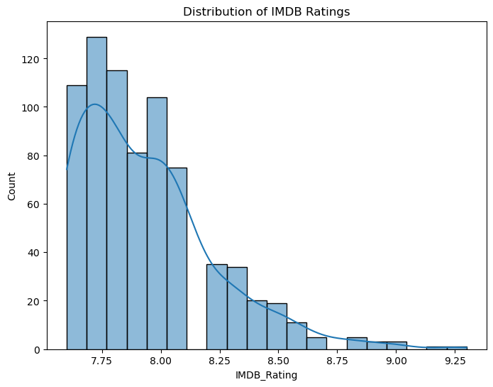

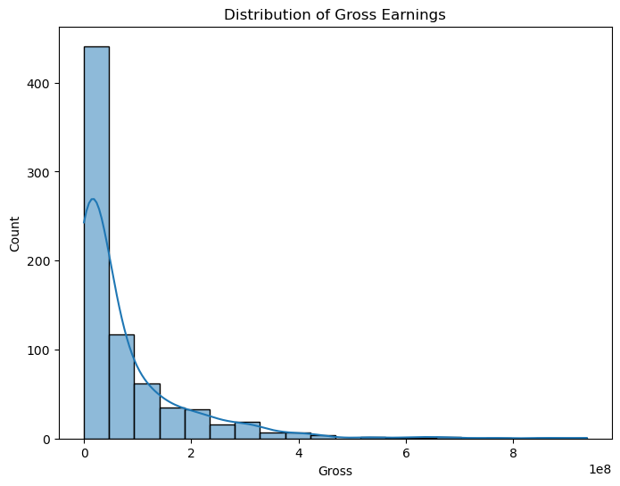

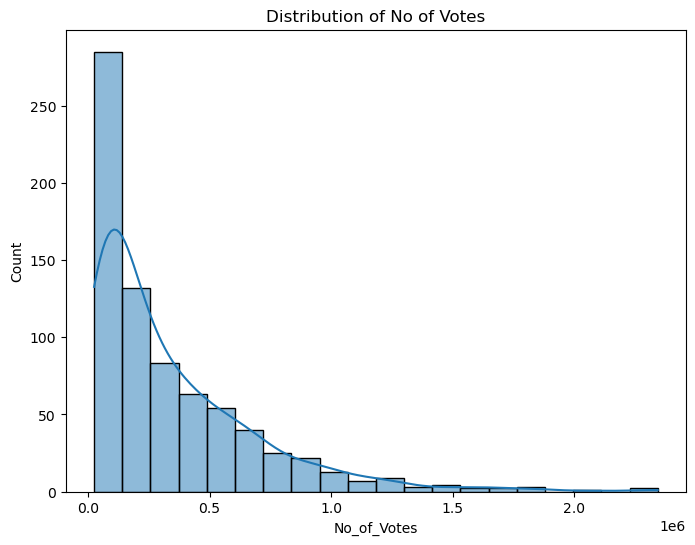

```python
import matplotlib.pyplot as plt
import seaborn as sns

# Summary Statistics
print(df.describe())

# Visualize the IMDB Rating distribution
plt.figure(figsize=(8, 6))
sns.histplot(df['IMDB_Rating'], kde=True, bins=20)
plt.title('Distribution of IMDB Ratings')
plt.show()

# Visualize Gross Earnings Distribution
plt.figure(figsize=(8, 6))
sns.histplot(df['Gross'], kde=True, bins=20)
plt.title('Distribution of Gross Earnings')
plt.show()

# Visualize No_of_Votes Distribution
plt.figure(figsize=(8, 6))
sns.histplot(df['No_of_Votes'], kde=True, bins=20)
plt.title('Distribution of No of Votes')
plt.show()
```

**4. K-Nearest Neighbors (K-NN) Classification:** Target Column & Model Training

- To begin with, I created a new target column called *high_rating*. This column helps classify movies based on their IMDB rating: if the rating is greater than 8, it’s marked as 1 (high rating), otherwise 0 (low rating). This turned the problem into a binary classification task.
- Next, I selected relevant features for training the model: *Runtime*, *Meta_score*, *No_of_Votes*, and *Gross*. These features seemed to have a significant relationship with movie ratings, so they were chosen to help the model make predictions.
- The dataset was then split into two parts: one for training the model and the other for testing its performance. This ensures the model is evaluated on unseen data, providing a more accurate assessment of how it would perform on real-world data.
- A K-Nearest Neighbors (K-NN) classifier was trained using 5 neighbors (k=5). This means the model looks at the 5 closest data points to make predictions about the target class (high or low rating).
- Finally, the model’s performance was evaluated, and the accuracy of its predictions was printed. This helped assess how well the model was able to predict whether a movie would have a high or low rating based on the selected features.

```
Accuracy: 70.67%
```

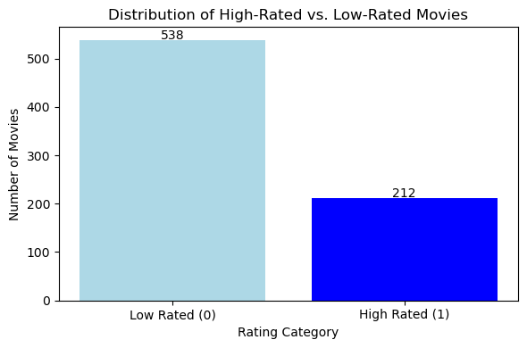

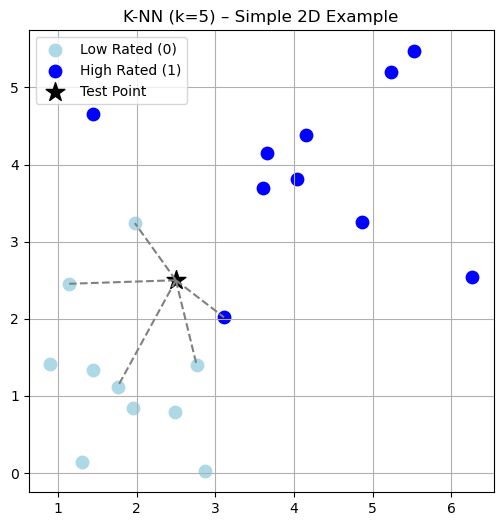

```python
import pandas as pd
import matplotlib.pyplot as plt
import numpy as np
from sklearn.model_selection import train_test_split
from sklearn.neighbors import KNeighborsClassifier
from sklearn.metrics import accuracy_score

# Create a 'high_rating' column as the target: 1 if IMDb Rating > 8, else 0
df['high_rating'] = df['IMDB_Rating'].apply(lambda x: 1 if x > 8 else 0)

# Features and target
X = df[['Runtime', 'Meta_score', 'No_of_Votes', 'Gross']]
y = df['high_rating']

# Split data
X_train, X_test, y_train, y_test = train_test_split(X, y, test_size=0.2, random_state=42)

# Train K-NN model
knn = KNeighborsClassifier(n_neighbors=5)
knn.fit(X_train, y_train)
y_pred = knn.predict(X_test)

# Accuracy
accuracy = accuracy_score(y_test, y_pred)
print(f"Accuracy: {accuracy * 100:.2f}%")

# Binary Target Bar Chart
rating_counts = df['high_rating'].value_counts().sort_index()
labels = ['Low Rated (0)', 'High Rated (1)']
colors = ['lightblue', 'blue']

plt.figure(figsize=(6, 4))
plt.bar(labels, rating_counts, color=colors)
plt.title('Distribution of High-Rated vs. Low-Rated Movies')
plt.ylabel('Number of Movies')
plt.xlabel('Rating Category')
for i, count in enumerate(rating_counts):
    plt.text(i, count + 1, f"{count}", ha='center')
plt.tight_layout()
plt.show()

# 2D K-NN Illustration
np.random.seed(0)
class_0 = np.random.randn(10, 2) + [1, 1]
class_1 = np.random.randn(10, 2) + [4, 4]
test_point = np.array([[2.5, 2.5]])

plt.figure(figsize=(6, 6))
plt.scatter(class_0[:, 0], class_0[:, 1], color='lightblue', label='Low Rated (0)', s=80)
plt.scatter(class_1[:, 0], class_1[:, 1], color='blue', label='High Rated (1)', s=80)
plt.scatter(test_point[0, 0], test_point[0, 1], color='black', marker='*', s=200, label='Test Point')

# Draw lines to k=5 nearest neighbors
all_points = np.vstack([class_0, class_1])
distances = np.linalg.norm(all_points - test_point, axis=1)
nearest_indices = distances.argsort()[:5]
for idx in nearest_indices:
    neighbor = all_points[idx]
    plt.plot([test_point[0, 0], neighbor[0]], [test_point[0, 1], neighbor[1]], 'gray', linestyle='--')

plt.title('K-NN (k=5) – Simple 2D Example')
plt.legend()
plt.grid(True)
plt.show()
```

**5. Confusion Matrix:** Comparison & Visualization

- After training and evaluating the K-NN model, I generated a confusion matrix to assess its performance in more detail. The confusion matrix helps compare the model’s predictions against the actual outcomes (whether a movie was high or low rated).
- The matrix shows four key values:
  - True Positives (TP): Correctly predicted high ratings
  - True Negatives (TN): Correctly predicted low ratings
  - False Positives (FP): Incorrectly predicted high ratings
  - False Negatives (FN): Incorrectly predicted low ratings
- To make the matrix easier to understand, I visualized it using a heatmap. This allows us to quickly see where the model is performing well and where it might be making mistakes, with darker colors representing higher values in the matrix.

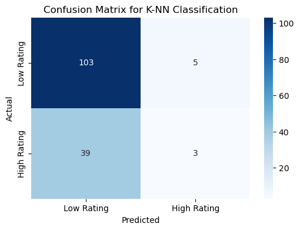

```python
import seaborn as sns
import matplotlib.pyplot as plt
from sklearn.metrics import confusion_matrix

# we have the predictions y_pred and actual values y_test from previous code
cm = confusion_matrix(y_test, y_pred)

# Plotting the confusion matrix
plt.figure(figsize=(6, 4))
sns.heatmap(cm, annot=True, fmt="d", cmap="Blues", xticklabels=['Low Rating', 'High Rating'], yticklabels=['Low Rating', 'High Rating'])

plt.title('Confusion Matrix for K-NN Classification')
plt.xlabel('Predicted')
plt.ylabel('Actual')
plt.show()
```

**6. K-NN Accuracy vs. k (Number of Neighbors):** Evaluation & Plot

- To understand how the number of neighbors (k) affects the K-NN model's performance, I evaluated the accuracy for different values of k, ranging from 1 to 20.
- For each value of k, I trained the model and calculated its accuracy, which measures how well the model’s predictions match the actual ratings.
- I then created a plot to visualize how accuracy changes as k increases. This helps identify the optimal value of k, where the model performs the best. A higher k might make the model more stable, while a lower k could lead to more overfitting.

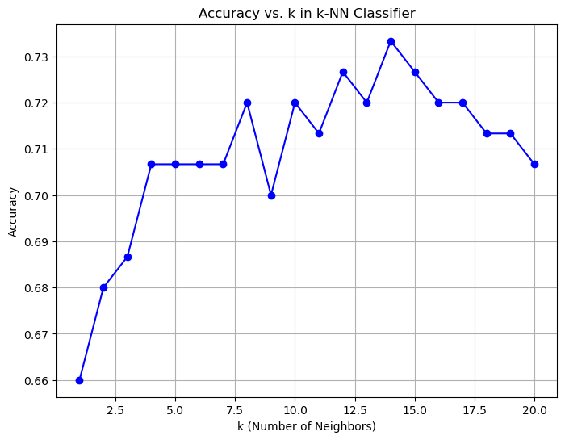

```python
import matplotlib.pyplot as plt
from sklearn.neighbors import KNeighborsClassifier
from sklearn.metrics import accuracy_score

# Initialize an empty list to store the accuracy values
accuracies = []

# Loop through different values of k
for k in range(1, 21):  # Example: testing k values from 1 to 20
    # Create a K-NN classifier with the current k value
    knn = KNeighborsClassifier(n_neighbors=k)

    # Fit the model on the training data
    knn.fit(X_train, y_train)

    # Make predictions
    y_pred = knn.predict(X_test)

    # Calculate accuracy
    accuracy = accuracy_score(y_test, y_pred)

    # Append the accuracy to the list
    accuracies.append(accuracy)

# Plot accuracy vs. k
plt.figure(figsize=(8, 6))
plt.plot(range(1, 21), accuracies, marker='o', color='b')
plt.title('Accuracy vs. k in k-NN Classifier')
plt.xlabel('k (Number of Neighbors)')
plt.ylabel('Accuracy')
plt.grid(True)
plt.show()
```

**7. K-Means** Clustering & Visualization

- For this analysis, I selected the features Runtime, IMDB_Rating, and Meta_score to group the movies into clusters based on these characteristics.
- To ensure the features are on a similar scale, I standardized the data using StandardScaler. This step helps improve the performance of the K-Means algorithm.
- I applied a K-Means clustering model, choosing 3 clusters to group the movies. This means the algorithm will try to find 3 distinct groups based on the selected features.
- Finally, I visualized the clustering results in a scatter plot. Each movie is plotted, with its cluster represented by different colors. The centroids (the center points of each cluster) are marked in red, showing the average position of each group.

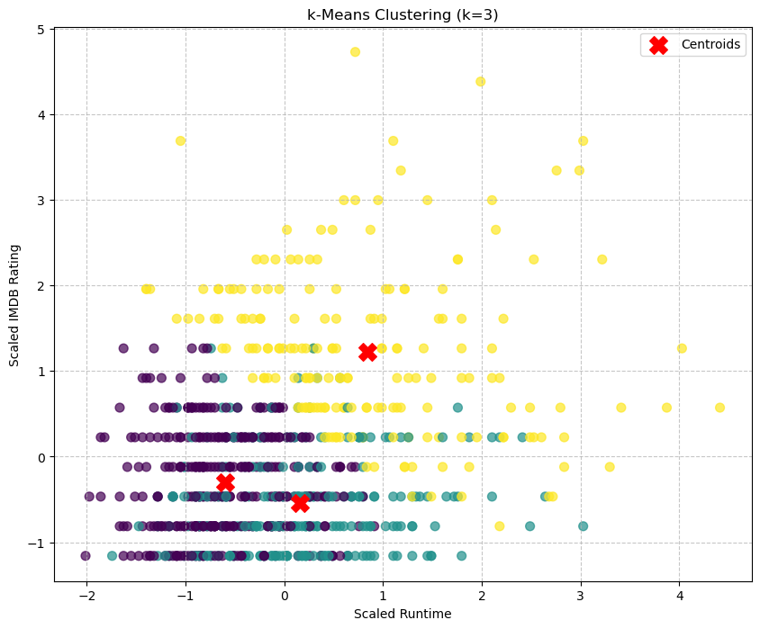

```python
import pandas as pd
import numpy as np
import matplotlib.pyplot as plt
from sklearn.cluster import KMeans
from sklearn.preprocessing import StandardScaler

# Select relevant features for clustering
X = df[['Runtime', 'IMDB_Rating', 'Meta_score']].values

# Standardize the features
scaler = StandardScaler()
X_scaled = scaler.fit_transform(X)

# Number of clusters
k = 3  # You can adjust the number of clusters

# Apply k-Means clustering
kmeans = KMeans(n_clusters=k, init='k-means++', random_state=42)
labels = kmeans.fit_predict(X_scaled)
centroids = kmeans.cluster_centers_

# Data visualization
plt.figure(figsize=(10, 8))
plt.scatter(X_scaled[:, 0], X_scaled[:, 1], c=labels, cmap='viridis', s=50, alpha=0.7)

# Mark centroids
plt.scatter(centroids[:, 0], centroids[:, 1], c='red', marker='X', s=200, label='Centroids')

# Labeling
plt.xlabel("Scaled Runtime")
plt.ylabel("Scaled IMDB Rating")
plt.title(f"k‑Means Clustering (k={k})")
plt.legend()
plt.grid(True, linestyle="--", alpha=0.7)
plt.show()
```

**8. HDBSCAN** Clustering & Visualization

- For this analysis, I used the same features as before: Runtime, IMDB_Rating, and Meta_score. These features help group the movies based on their characteristics.
- To prepare the data, I standardized it to ensure that all features are on a similar scale, making the clustering process more effective.
- I then applied HDBSCAN (Hierarchical Density-Based Spatial Clustering of Applications with Noise) to find clusters within the data. HDBSCAN is particularly good at identifying clusters of varying shapes and densities, which is useful for this kind of dataset.
- The clustering results were visualized in a scatter plot, where each point (movie) is colored according to its cluster. This helps to easily see which movies group together based on their features.

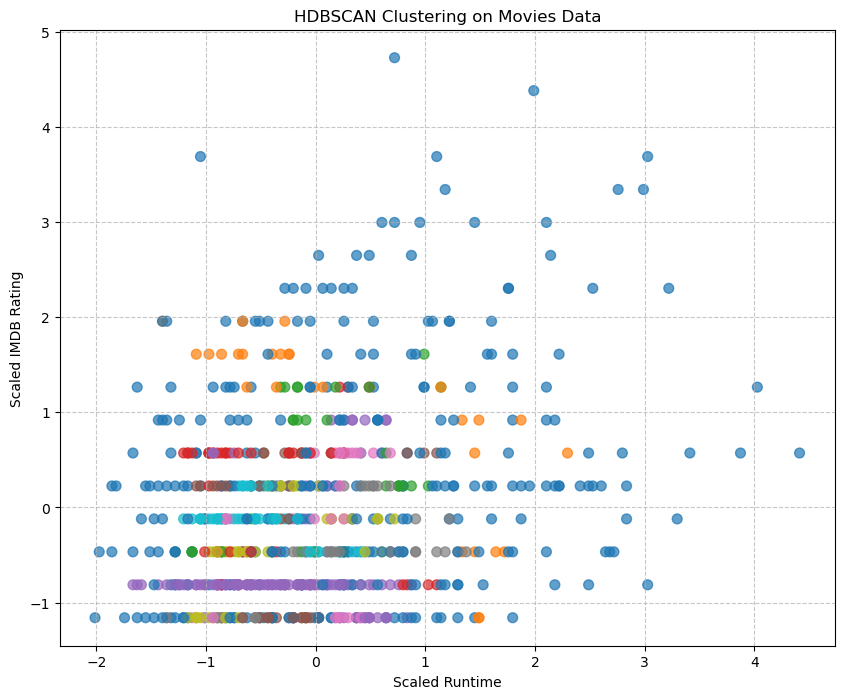

```
Number of clusters found by HDBSCAN (excluding noise): 91
```

```python
import pandas as pd
import numpy as np
import matplotlib.pyplot as plt
from sklearn.preprocessing import StandardScaler
import hdbscan

# Select relevant features for clustering
X = df[['Runtime', 'IMDB_Rating', 'Meta_score']].values

# Standardize the features
scaler = StandardScaler()
X_scaled = scaler.fit_transform(X)

# Apply HDBSCAN clustering
clusterer = hdbscan.HDBSCAN(min_cluster_size=2, min_samples=2)
hdb_labels = clusterer.fit_predict(X_scaled)

# Visualize HDBSCAN clusters
plt.figure(figsize=(10, 8))
plt.scatter(X_scaled[:, 0], X_scaled[:, 1], c=hdb_labels, cmap='tab10', s=50, alpha=0.7)

# Labeling
plt.xlabel("Scaled Runtime")
plt.ylabel("Scaled IMDB Rating")
plt.title("HDBSCAN Clustering on Movies Data")
plt.grid(True, linestyle="--", alpha=0.7)
plt.show()

# Count the number of clusters
num_clusters = len(set(hdb_labels)) - (1 if -1 in hdb_labels else 0)
print(f"Number of clusters found by HDBSCAN (excluding noise): {num_clusters}")
```

```
Optimal k based on silhouette analysis: 3
```

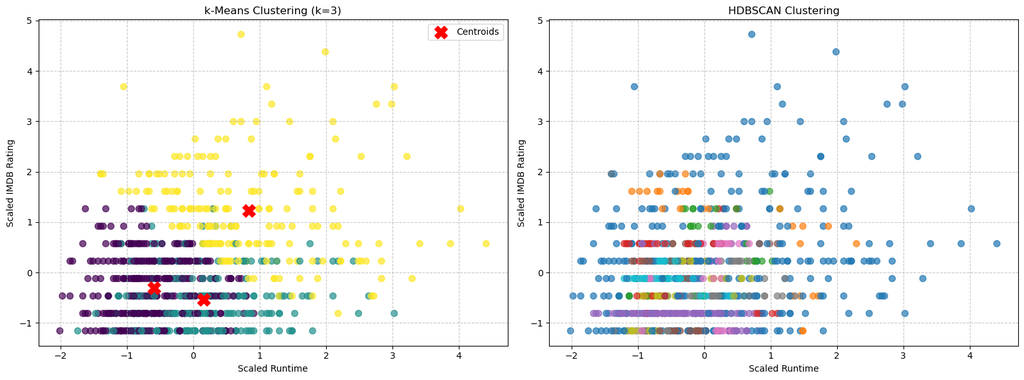

```python
import pandas as pd
import numpy as np
import matplotlib.pyplot as plt
from sklearn.cluster import KMeans
from sklearn.preprocessing import StandardScaler
from sklearn.metrics import silhouette_score
import hdbscan


# Select relevant features for clustering
X = df[['Runtime', 'IMDB_Rating', 'Meta_score']].values

# Standardize the features
scaler = StandardScaler()
X_scaled = scaler.fit_transform(X)

# Silhouette analysis to find optimal k
k_values = range(3, 4)  # Trying k=2 to k=5, for example
silhouette_scores = []

for k in k_values:
    km = KMeans(n_clusters=k, init='k-means++', random_state=42, n_init='auto')
    km_labels = km.fit_predict(X_scaled)
    silhouette_avg = silhouette_score(X_scaled, km_labels)
    silhouette_scores.append(silhouette_avg)

optimal_k = k_values[silhouette_scores.index(max(silhouette_scores))]
print(f"Optimal k based on silhouette analysis: {optimal_k}")

# K-Means clustering with optimal k
km = KMeans(n_clusters=optimal_k, init='k-means++', random_state=42, n_init='auto')
km_labels = km.fit_predict(X_scaled)
km_centroids = km.cluster_centers_

# Apply HDBSCAN clustering
clusterer = hdbscan.HDBSCAN(min_cluster_size=2, min_samples=2)
hdb_labels = clusterer.fit_predict(X_scaled)

# Prepare 2D visualization data
fig, axs = plt.subplots(1, 2, figsize=(16, 6))

# Plot k-Means clustering result
axs[0].scatter(X_scaled[:, 0], X_scaled[:, 1], c=km_labels, cmap='viridis', s=50, alpha=0.7)
axs[0].scatter(km_centroids[:, 0], km_centroids[:, 1], c='red', marker='X', s=200, label='Centroids')
axs[0].set_title(f"k-Means Clustering (k={optimal_k})")
axs[0].set_xlabel("Scaled Runtime")
axs[0].set_ylabel("Scaled IMDB Rating")
axs[0].legend()
axs[0].grid(True, linestyle="--", alpha=0.7)

# Plot HDBSCAN clustering result
axs[1].scatter(X_scaled[:, 0], X_scaled[:, 1], c=hdb_labels, cmap='tab10', s=50, alpha=0.7)
axs[1].set_title("HDBSCAN Clustering")
axs[1].set_xlabel("Scaled Runtime")
axs[1].set_ylabel("Scaled IMDB Rating")
axs[1].grid(True, linestyle="--", alpha=0.7)

plt.tight_layout()
plt.show()
```